# Reproducible Research: Peer Assessment 1

### Abstract

In this assignment we are analyzing the walking activity of a single person over the course of two months. The analysis will show when the person was active and when they were not.

## Loading and preprocessing the data

Load and pre-process the data by converting the “steps” column to numeric which will be useful later and add a day type indicating whether the given day (indicated by the “date” column) is a week day or a weekend day so that we can compare and contrast week day activity to weekend activity.

```r
library(data.table)
library(ggplot2)

setwd("/Users/cching/Coursera/Reproducible Research/RepData_PeerAssessment1")

# Load the data set
if (!file.exists("activity.csv")) unzip("activity.zip")
data <- data.table(read.csv("activity.csv", stringsAsFactors = FALSE))

# Convert steps to numeric, this is useful when we do the impute
# step later to fill in imputed values for missing data
data <- data[, steps := as.numeric(steps)]

# Add a daytype column indicating if the day is a week day
# or weekend day
data <- data[, daytype := ifelse(
    weekdays(as.Date(date)) == "Saturday" |
        weekdays(as.Date(date)) == "Sunday", "weekend", "weekday")]

# Set knitr options to control the number of significant digits
options(scipen = 1, digits = 7)
```

## What is mean total number of steps taken per day?

The analysis done here is intended to show a distribution of total steps taken per day and report the mean and median values of the total steps. The analysis ignores any missing values.

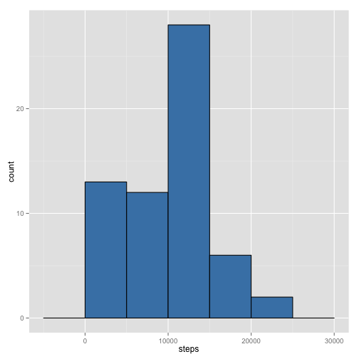

```r
totals <- data[, list(steps = sum(steps, na.rm = TRUE)), by = date]
totals_mean <- round(totals[, mean(steps)], digits = 0)
totals_median <- totals[, median(steps)]
ggplot(totals, aes(x = steps)) +
    geom_histogram(binwidth = 5000, colour = "black", fill = "steelblue")
```

The mean total steps taken per day is 9354 and the median is 10395.

## What is the average daily activity pattern?

The analysis done here is intended to give an idea of the activity patterns of the individual at intervals during the day. The mean per 5 minute interval is given and the interval with the highest mean number of steps is shown indicating what part of the day the individual was most active.

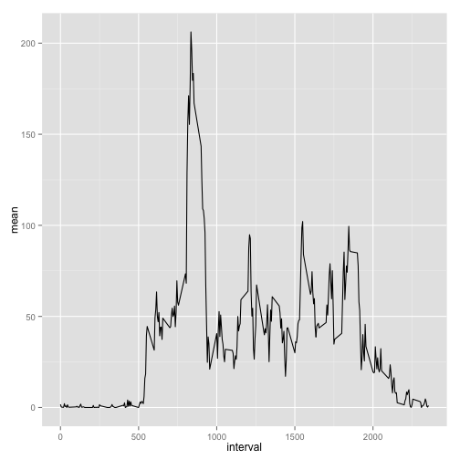

```r
avgs <- data[, list(mean = mean(steps, na.rm = TRUE)), by = interval]
max_avgs <- avgs[avgs[, mean == max(mean)], ]
qplot(interval, mean, data = avgs, geom = "line")
```

The interval with the maximum average number of steps is 835 with a value of 206. There appears to be a pretty consistent burst of activity in the morning, possibly indicating some sort of daily exercise routine or walk.

## Imputing missing values

In this analysis we devise a method for imputing the missing values and carry out the same analysis done in the section “What is the mean total number of steps taken per day?” to show the effect of trying to account for the missing data. Our method for imputing the missing data is to use the mean of the total steps taken for the given interval.

First, ensure that the missing values are only in the “steps” column of the data set:

```r
# Compare complete.cases with is.na(steps), if the same
# then all NA are in steps
str <- if (sum(!complete.cases(data)) == sum(is.na(data$steps))) {
    "The \"steps\" column is the only column with missing data."
} else {
    "Columns other than \"steps\" contain missing data."
}
```

The “steps” column is the only column with missing data.

Next, carry out replacing missing values with the means for the interval calcuated previously.

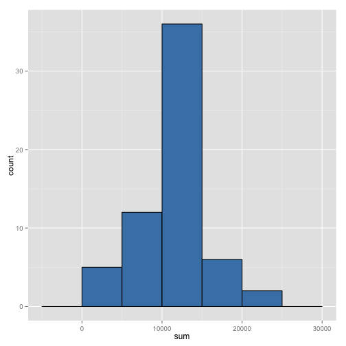

```r
# The following for loop is *slow*, I welcome any comments in my evaluation
# that show how to do this faster with a data.table or otherwise!
for (i in 1:nrow(data)) {

    if (is.na(data[i]$steps)) {
        data[i]$steps = avgs[interval == data[i]$interval]$mean
    }
}

totals <- data[, list(sum = sum(steps, na.rm = TRUE)), by = date]
totals_mean <- round(mean(totals$sum), digits = 0)
totals_median <- round(median(totals$sum), digits = 0)
ggplot(totals, aes(x = sum)) +
    geom_histogram(binwidth = 5000, colour = "black", fill = "steelblue")
```

The mean total steps with our imputing strategy is 10766 and the median is 10766.

The effect of using the mean total value for an interval with missing data appears to make the distribution more “normal” and to inflate the number of intervals with the overall mean total value.

## Are there differences in activity patterns between weekdays and weekends?

This analysis is intended to show the difference in activity between week days and weekend days.

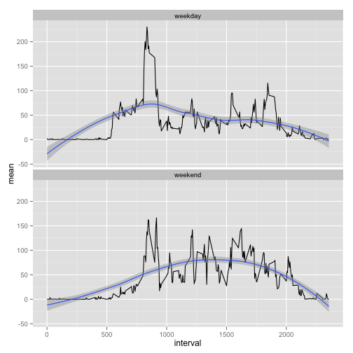

```r
avgs <- data[, list(mean = mean(steps, na.rm = TRUE)), by = list(interval, daytype)]
qplot(interval, mean, data = avgs, facets = . ~ daytype, geom = c("line", "smooth"), method = "loess") +
    facet_wrap(~ daytype, nrow = 2, ncol = 1)
```

It appears that activity on the weekends is sustained at a slightly higher rate. A loess smooth was added to bring out this characteristic in the data. It also shows a spike in activity around the same time between week days and weekend days further strengthening the idea that there is some sort of exercise routine carried out earlier in the day.